# JSON Github

### Project Name : Call to Action based on JSON File

### 1. Objective

The main objective of this asignment is to derive insights and useful data from a JSON file. The Json file that I have selected contains details about the standings in the English Premier League for the 2014 season. The data contains details about the points scored, rank at which each club finished as well as wins, draws and losses.

My objectives is to run analysis on this data and to derive some insights from this data which will help teams for theirpreparation for next season.

```python
import json
```

```python
with open('EPL1.json', 'r') as J1:
    dict = json.load(J1)
```

```python
type(dict)
```

```
list
```

### 2. Data Mining

```python
print(dict[9])
```

```
{'rank': 10, 'team': 'Newcastle United', 'played': 38, 'wins': 15, 'draws': 4, 'losses': 19, 'goals-for': 43, 'goals-against': 59, 'goals-dff': -16, 'points': 49}
```

Here I have displayed the average of total points scored

```python
a = 0
for distro in dict:
    a += distro['points']
```

```python
a
```

```
1062
```

```python
avg = a/20
avg
```

```
53.1
```

Here I have displayed the highest number of goals scored by a team

```python
a1 = []

for p1 in dict:
    a1 += (p1['goals-for'],)
```

```python
max(a1)
```

```
102
```

```python
print(dict[0])
```

```
{'rank': 1, 'team': 'Manchester City', 'played': 38, 'wins': 27, 'draws': 5, 'losses': 6, 'goals-for': 102, 'goals-against': 37, 'goals-dff': '+65', 'points': 86}
```

```python
WinPer = (27/38)*100
WinPer
```

```
71.05263157894737
```

Here I have displayed the winning percentage of the team which won the league.

Here I have displayed the total number of goals scored by all the teams in a season

```python
a3 = 0
for distro in dict:
    a3 += distro['goals-for']
```

```python
a3
```

```
1052
```

Here I take input from the user to display the team which finished at a rank which is taken as input from the user.

The input can be from 0 to 19 which are the total ranks of teams in the league.

```python
d1 = input("Enter rank :")
d2 = int(d1)
print(dict[d2])
```

```
Enter rank :3
{'rank': 4, 'team': 'Arsenal', 'played': 38, 'wins': 24, 'draws': 7, 'losses': 7, 'goals-for': 68, 'goals-against': 41, 'goals-dff': '+27', 'points': 79}
```

```python
print(dict[17])
```

```
{'rank': 18, 'team': 'Norwich City', 'played': 38, 'wins': 8, 'draws': 9, 'losses': 21, 'goals-for': 28, 'goals-against': 62, 'goals-dff': -34, 'points': 33}
```

```python
Perc = (8/38)*100
Perc
```

```
21.052631578947366
```

For a team to not be relegated to a lower division, the team needs to maintain a win percentage of atleast 21%.

### 3. Plots

Here I have split the file and separated various entries into different variables for the purpose of plotting.

```python
import matplotlib.pyplot as plt
```

```python
az = []
bz = []
cz = []
dz = []
ez = []
fz = []
gz = []

for distro in dict:
    az += (distro['team'],)
    bz += (distro['points'],)
    cz += (distro['goals-for'],)
    dz += (distro['wins'],)
    ez += (distro['draws'],)
    fz += (distro['losses'],)
    gz += (distro['rank'],)
```

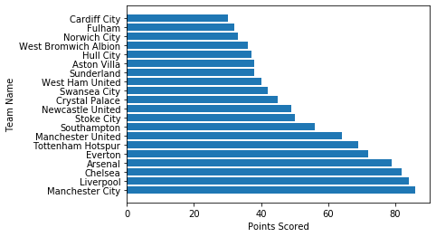

```python
plt.barh(az, bz)
plt.xlabel('Points Scored')
plt.ylabel('Team Name')
plt.show()
```

Here I have displayed the points scored by each team over the course of the season.

As we can see, Manchester City who won the league have accumulated the most points.

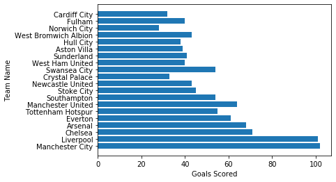

```python
plt.barh(az, cz)
plt.xlabel('Goals Scored')
plt.ylabel('Team Name')
plt.show()
```

Here I have displayed the number of goals scored by all the teams in the league

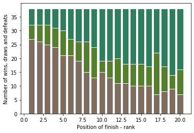

```python
import numpy as np

bars = np.add(dz, ez).tolist()


plt.bar(gz, dz, color='#7f6d5f', edgecolor='white')
# Create green bars (middle), on top of the firs ones
plt.bar(gz, ez, bottom=dz, color='#557f2d', edgecolor='white')
# Create green bars (top)
plt.bar(gz, fz, bottom=bars, color='#2d7f5e', edgecolor='white')

plt.xlabel('Position of finish - rank')
plt.ylabel('Number of wins, draws and defeats')
plt.figure(figsize = (25,25))

plt.show()
```

Here I have displayed the wins, draws and defeats suffered by each team in a stacked bar plot.

### 5. Recommendations

1. For a team to finish in the top half of the table, a team has to score 53 points - which is the average score and is greater than the number of points scored by the team which finished 10th.
1. For a team to win the league they need to score at least about 100 goals in the season.
1. For a team to win the league, they need to win more than 71% of their matches.
1. For a team to not be relegated to a lower division, the team needs to win at least 20% of their matches.